# Supplementary Analysis: Excitatory Neuron Classification in Postnatal PsychAD Cells

## 2 Raw Marker Expression Confirms a Genuine EN Deficit in PsychAD Infants

Having excluded technical confounders, we examined raw count-derived marker expression using CPM values computed directly from each source’s un-integrated count matrix.

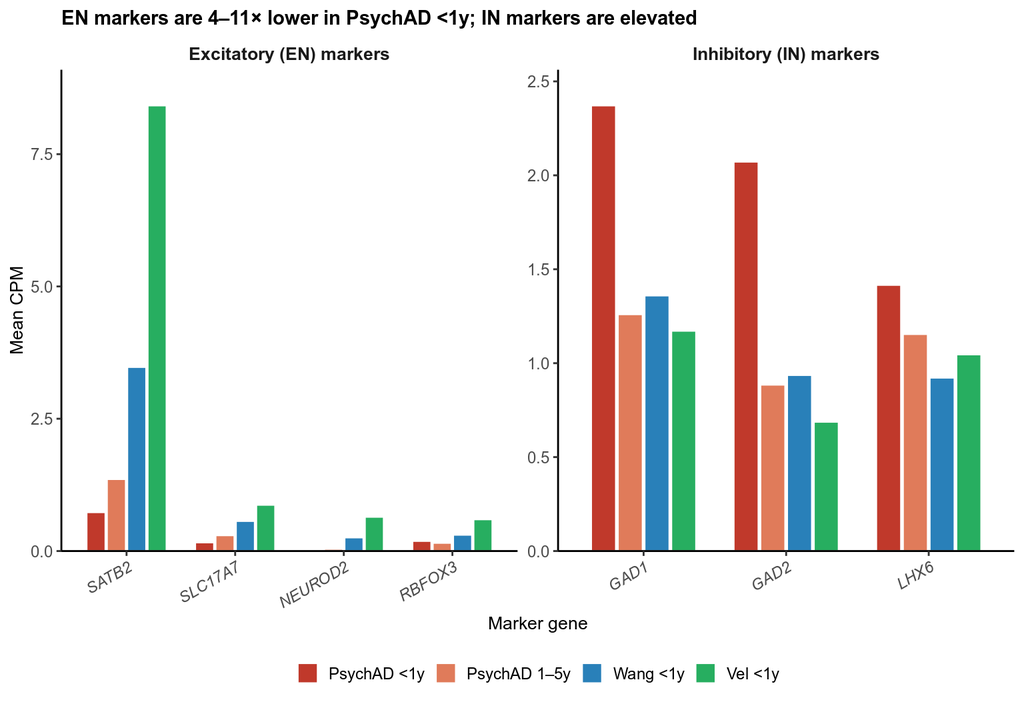

```r
cpm_raw <- read_csv(file.path(BASE, "no_age_run", "marker_means_raw_cpm.csv"),
                    show_col_types = FALSE) |>
  filter(group %in% c("PSYCHAD_under1y", "PSYCHAD_1_5y",
                       "WANG_under1y",    "VEL_V3_under1y")) |>
  filter(marker %in% c("SATB2", "SLC17A7", "NEUROD2", "RBFOX3",
                        "GAD1",  "GAD2",    "LHX6")) |>
  mutate(
    group_label = recode(group,
      "PSYCHAD_under1y" = "PsychAD <1y",
      "PSYCHAD_1_5y"    = "PsychAD 1–5y",
      "WANG_under1y"    = "Wang <1y",
      "VEL_V3_under1y"  = "Vel <1y"
    ),
    group_label = factor(group_label,
                         levels = c("PsychAD <1y", "PsychAD 1–5y",
                                    "Wang <1y", "Vel <1y")),
    marker_type_label = if_else(marker_type == "EN",
                                "Excitatory (EN) markers",
                                "Inhibitory (IN) markers"),
    marker = factor(marker, levels = c("SATB2", "SLC17A7", "NEUROD2", "RBFOX3",
                                        "GAD1",  "GAD2",    "LHX6"))
  )

p_cpm <- ggplot(cpm_raw, aes(x = marker, y = mean_norm, fill = group_label)) +
  geom_col(position = position_dodge(width = 0.75), width = 0.7, colour = "white") +
  scale_fill_manual(values = GROUP_COLORS) +
  scale_y_continuous(expand = expansion(mult = c(0, 0.08))) +
  facet_wrap(~marker_type_label, scales = "free") +
  labs(
    x     = "Marker gene",
    y     = "Mean CPM",
    title = "EN markers are 4–11× lower in PsychAD <1y; IN markers are elevated"
  ) +
  theme_pub() +
  theme(
    legend.position = "bottom",
    axis.text.x     = element_text(face = "italic", angle = 30, hjust = 1)
  )

p_cpm
```

This pattern is consistent with a genuine preponderance of cortical interneurons at the expense of pyramidal cells in the PsychAD DLPFC sample. However, the magnitude of the deficit relative to Wang and Vel — sourced from the same developmental window — suggests additional sources of variance that we examine below.

## 3 Per-Cell Marker Detectability Confirms the Composition Shift

The CPM analysis above reflects mean expression per cell summed across the population; high expression in a minority of cells can inflate the mean. We therefore examined the fraction of cells with detectable expression (UMI ≥ 1) for each marker independently.

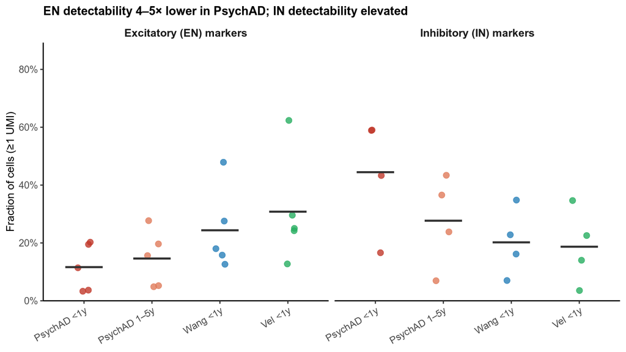

```r
d12 <- read_csv(file.path(BASE, "d11_d12_d13", "d12_frac_nonzero.csv"),
                show_col_types = FALSE) |>
  mutate(
    group_label = recode(group,
      "PSYCHAD_under1y" = "PsychAD <1y",
      "PSYCHAD_1_5y"    = "PsychAD 1–5y",
      "WANG_under1y"    = "Wang <1y",
      "VEL_V3_under1y"  = "Vel <1y"
    ),
    group_label = factor(group_label,
                         levels = c("PsychAD <1y", "PsychAD 1–5y",
                                    "Wang <1y",    "Vel <1y"))
  ) |>
  select(group_label,
         EN_SATB2    = EN_SATB2_frac1,
         EN_SLC17A7  = EN_SLC17A7_frac1,
         EN_NEUROD2  = EN_NEUROD2_frac1,
         EN_RBFOX3   = EN_RBFOX3_frac1,
         EN_TBR1     = EN_TBR1_frac1,
         IN_GAD1     = IN_GAD1_frac1,
         IN_GAD2     = IN_GAD2_frac1,
         IN_LHX6     = IN_LHX6_frac1,
         IN_SLC32A1  = IN_SLC32A1_frac1) |>
  pivot_longer(-group_label, names_to = c("type", "marker"),
               names_sep = "_(?=[A-Z])", values_to = "frac_nonzero") |>
  mutate(
    marker_type_label = if_else(type == "EN",
                                "Excitatory (EN) markers",
                                "Inhibitory (IN) markers")
  )

# Means for dashed connectors
d12_means <- d12 |>
  group_by(group_label, marker_type_label) |>
  summarise(mean_frac = mean(frac_nonzero), .groups = "drop") |>
  pivot_wider(names_from = marker_type_label, values_from = mean_frac)

d12_long_means <- d12 |>
  group_by(group_label, marker_type_label) |>
  summarise(mean_frac = mean(frac_nonzero), .groups = "drop")

p_frac <- ggplot(d12, aes(x = group_label, y = frac_nonzero, colour = group_label)) +
  geom_jitter(width = 0.12, size = 2.5, alpha = 0.8, stroke = 0.3) +
  stat_summary(fun = mean, geom = "crossbar",
               width = 0.55, linewidth = 0.6, fatten = 1.5,
               colour = "grey20") +
  scale_colour_manual(values = GROUP_COLORS, guide = "none") +
  scale_y_continuous(labels = label_percent(accuracy = 1),
                     limits = c(0, 0.85),
                     expand = expansion(mult = c(0, 0.05))) +
  facet_wrap(~marker_type_label) +
  labs(
    x     = NULL,
    y     = "Fraction of cells (≥1 UMI)",
    title = "EN detectability 4–5× lower in PsychAD; IN detectability elevated"
  ) +
  theme_pub() +
  theme(axis.text.x = element_text(angle = 30, hjust = 1))

p_frac
```

Notably, the 1–5 year PsychAD group shows intermediate EN detectability (15%) and reduced IN detectability (28%) relative to the <1y group, suggesting a partial developmental trajectory — albeit one that does not reach the Wang/Vel level even by age 5.

## 4 Within-Cohort Donor Analysis Shows No Age Gradient

A potential confound within the PsychAD <1y group is age heterogeneity: if the youngest donors (1 month) have genuinely lower EN fractions than donors at 4–6 months, the bulk aggregate could mask a biologically coherent developmental signal.

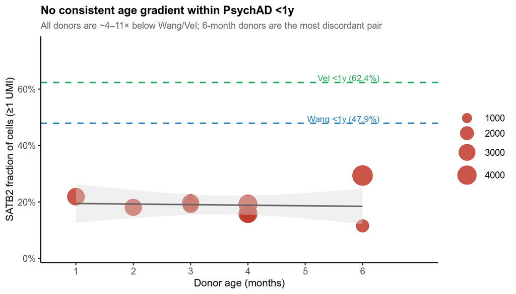

```r
d11 <- read_csv(file.path(BASE, "d11_d12_d13", "d11_per_donor.csv"),
                show_col_types = FALSE)

# Wang and Vel SATB2_frac1 reference lines from d12
wang_satb2 <- d12 |>
  filter(group_label == "Wang <1y", marker == "SATB2") |>
  pull(frac_nonzero)
vel_satb2 <- d12 |>
  filter(group_label == "Vel <1y",  marker == "SATB2") |>
  pull(frac_nonzero)

p_donor <- ggplot(d11, aes(x = age_months, y = SATB2_frac1)) +
  geom_hline(yintercept = wang_satb2,
             colour = GROUP_COLORS["Wang <1y"], linetype = "dashed", linewidth = 0.7) +
  geom_hline(yintercept = vel_satb2,
             colour = GROUP_COLORS["Vel <1y"],  linetype = "dashed", linewidth = 0.7) +
  annotate("text", x = 6.3, y = wang_satb2 + 0.015,
           label = paste0("Wang <1y (", percent(wang_satb2, accuracy = 0.1), ")"),
           colour = GROUP_COLORS["Wang <1y"], size = 3, hjust = 1) +
  annotate("text", x = 6.3, y = vel_satb2 + 0.015,
           label = paste0("Vel <1y (", percent(vel_satb2, accuracy = 0.1), ")"),
           colour = GROUP_COLORS["Vel <1y"], size = 3, hjust = 1) +
  geom_point(aes(size = n_cells),
             colour = GROUP_COLORS["PsychAD <1y"], alpha = 0.85, stroke = 0.3) +
  geom_smooth(method = "lm", formula = y ~ x,
              colour = "grey40", fill = "grey85", linewidth = 0.7, se = TRUE) +
  scale_x_continuous(breaks = 1:6, limits = c(0.7, 7)) +
  scale_y_continuous(labels = label_percent(accuracy = 1),
                     limits = c(0, 0.75),
                     expand = expansion(mult = c(0.02, 0.05))) +
  scale_size_area(max_size = 9, name = "Cells per donor") +
  labs(
    x     = "Donor age (months)",
    y     = "SATB2 fraction of cells (≥1 UMI)",
    title = "No consistent age gradient within PsychAD <1y",
    subtitle = "All donors are ~4–11× below Wang/Vel; 6-month donors are the most discordant pair"
  ) +
  theme_pub() +
  theme(legend.position = "right")

p_donor
```

The linear trend across 1–6 months is flat and non-significant; the two 6-month donors (Donor_202: 11.5%; Donor_503: 29.4%) bracket the entire cohort distribution. SATB2 retention (≥3 UMI / ≥1 UMI, measuring per-cell expression intensity among SATB2-expressing cells) has a donor mean of **0.31 ± 0.08** in PsychAD <1y versus **0.77** in Wang and **0.75** in Vel — a deficit that is consistent across all 11 donors and not explained by any obvious technical covariate (Table S1 shows per-donor metadata).

```r
knitr::kable(
  d11 |>
    select(Donor = individual,
           `Age (mo.)` = age_months,
           `Stage` = development_stage,
           `N cells` = n_cells,
           `UMI/cell` = total_UMI_mean,
           `SATB2 frac1` = SATB2_frac1,
           `SATB2 ret.` = SATB2_retention,
           `GAD1 frac1` = GAD1_frac1) |>
    mutate(across(where(is.double), ~round(., 3))),
  caption = "**Table S1.** Per-donor summary for PsychAD <1y group (sorted by age).
  SATB2 ret. = fraction of SATB2-positive cells with ≥3 UMI (expression intensity proxy).
  Donor_920 has only 392 cells and should be interpreted cautiously.",
  align = c("l", "r", "l", "r", "r", "r", "r", "r")
)
```

Table 1: **Table S1.** Per-donor summary for PsychAD <1y group (sorted by age). SATB2 ret. = fraction of SATB2-positive cells with ≥3 UMI (expression intensity proxy). Donor_920 has only 392 cells and should be interpreted cautiously.

**Table S1.** Per-donor summary for PsychAD <1y group (sorted by age). SATB2 ret. = fraction of SATB2-positive cells with ≥3 UMI (expression intensity proxy). Donor_920 has only 392 cells and should be interpreted cautiously.

| Donor | Age (mo.) | Stage | N cells | UMI/cell | SATB2 frac1 | SATB2 ret. | GAD1 frac1 |
| --- | --- | --- | --- | --- | --- | --- | --- |
| Donor_122 | 1 | 1-month-old stage | 3324 | 9438.848 | 0.219 | 0.249 | 0.644 |
| Donor_1208 | 2 | 2-month-old stage | 3140 | 20451.714 | 0.181 | 0.213 | 0.696 |
| Donor_316 | 3 | 3-month-old stage | 3103 | 14872.723 | 0.197 | 0.284 | 0.593 |
| Donor_594 | 3 | 3-month-old stage | 2707 | 14014.397 | 0.189 | 0.315 | 0.608 |
| Donor_920 | 3 | 3-month-old stage | 392 | 21214.883 | 0.217 | 0.447 | 0.620 |
| Donor_47 | 4 | 4-month-old stage | 2729 | 17130.724 | 0.164 | 0.393 | 0.601 |
| Donor_1326 | 4 | 4-month-old stage | 3875 | 12055.201 | 0.192 | 0.434 | 0.603 |
| Donor_1171 | 4 | 4-month-old stage | 2803 | 20543.369 | 0.156 | 0.407 | 0.542 |
| Donor_648 | 4 | 4-month-old stage | 3847 | 11969.055 | 0.159 | 0.231 | 0.517 |
| Donor_202 | 6 | 6-month-old stage | 1772 | 8597.683 | 0.115 | 0.123 | 0.414 |
| Donor_503 | 6 | 6-month-old stage | 4565 | 18544.581 | 0.294 | 0.330 | 0.598 |

## 5 Ambient RNA Contamination Does Not Explain Elevated IN Signal

High IN marker CPM in PsychAD cells could arise not from genuine interneuron content but from ambient RNA contamination if the droplet suspension is enriched for nuclear fragments expressing GAD1/GAD2. We tested this by computing IN marker levels in cells classified as *non-neuronal* by the source-native PsychAD annotation (HBCC cohort `class` column: Astro, Oligo, OPC, Mural, Endo, Immune) — cells that should not express interneuron markers in the absence of contamination.

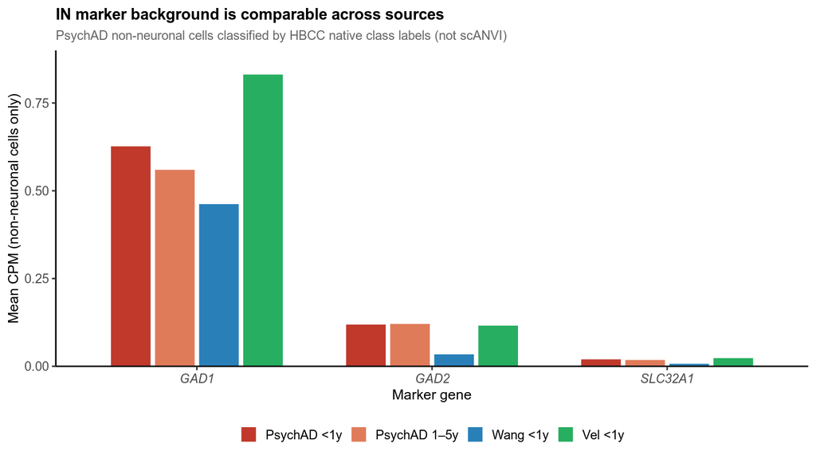

Figure 6: **Figure S6.** IN marker expression in non-neuronal cells, classified by source-native labels (HBCC `class` for PsychAD; scANVI `cell_type_aligned` for Wang/Vel). CPM is computed from raw counts for cells not assigned to EN or IN classes. If elevated GAD1/GAD2 in PsychAD non-neuronal cells were driven by ambient RNA, the PsychAD bars would substantially exceed Wang/Vel. The observed pattern shows PsychAD intermediate between Wang and Vel for GAD1, and comparable for GAD2 and SLC32A1. This argues against ambient contamination as the explanation for elevated IN signal in PsychAD infants.

```r
d13b <- read_csv(file.path(BASE, "d11_d12_d13", "d13b_ambient_native_labels.csv"),
                 show_col_types = FALSE) |>
  mutate(
    group_label = recode(group,
      "PSYCHAD_under1y" = "PsychAD <1y",
      "PSYCHAD_1_5y"    = "PsychAD 1–5y",
      "WANG_under1y"    = "Wang <1y",
      "VEL_V3_under1y"  = "Vel <1y"
    ),
    group_label = factor(group_label,
                         levels = c("PsychAD <1y", "PsychAD 1–5y",
                                    "Wang <1y", "Vel <1y"))
  ) |>
  select(group_label, label_source, n_nonneuronal,
         GAD1 = GAD1_mean_cpm, GAD2 = GAD2_mean_cpm, SLC32A1 = SLC32A1_mean_cpm) |>
  pivot_longer(c(GAD1, GAD2, SLC32A1), names_to = "marker", values_to = "mean_cpm") |>
  mutate(marker = factor(marker, levels = c("GAD1", "GAD2", "SLC32A1")))

p_ambient <- ggplot(d13b, aes(x = marker, y = mean_cpm, fill = group_label)) +
  geom_col(position = position_dodge(width = 0.75), width = 0.7, colour = "white") +
  scale_fill_manual(values = GROUP_COLORS) +
  scale_y_continuous(expand = expansion(mult = c(0, 0.08))) +
  labs(
    x     = "Marker gene",
    y     = "Mean CPM (non-neuronal cells only)",
    title = "IN marker background is comparable across sources",
    subtitle = "PsychAD non-neuronal cells classified by HBCC native class labels (not scANVI)"
  ) +
  theme_pub() +
  theme(legend.position = "bottom",
        axis.text.x = element_text(face = "italic"))

p_ambient
```

```r
d13b_wide <- read_csv(file.path(BASE, "d11_d12_d13", "d13b_ambient_native_labels.csv"),
                      show_col_types = FALSE) |>
  mutate(
    group_label = recode(group,
      "PSYCHAD_under1y" = "PsychAD <1y",
      "PSYCHAD_1_5y"    = "PsychAD 1–5y",
      "WANG_under1y"    = "Wang <1y",
      "VEL_V3_under1y"  = "Vel <1y"
    )
  ) |>
  select(`Group` = group_label,
         `Label source` = label_source,
         `Non-neuronal` = n_nonneuronal,
         `Neuronal` = n_neuronal,
         `EN CPM` = EN_mean_cpm,
         `IN CPM` = IN_mean_cpm,
         `IN/EN` = IN_over_EN_nonneuronal,
         `GAD1 CPM` = GAD1_mean_cpm) |>
  mutate(across(where(is.double), ~round(., 3)))

knitr::kable(d13b_wide,
  caption = "**Table S2.** IN/EN marker CPM in non-neuronal cells by source. Label source indicates
  which annotation was used to identify non-neuronal cells. The IN/EN ratio in PsychAD non-neuronal
  cells is elevated relative to Wang/Vel but is consistent with the Vel prenatal group, which also
  uses FANS nuclear isolation and has well-characterised ambient contamination levels."
)
```

**Table S2.** IN/EN marker CPM in non-neuronal cells by source. Label source indicates which annotation was used to identify non-neuronal cells. The IN/EN ratio in PsychAD non-neuronal cells is elevated relative to Wang/Vel but is consistent with the Vel prenatal group, which also uses FANS nuclear isolation and has well-characterised ambient contamination levels.

| Group | Label source | Non-neuronal | Neuronal | EN CPM | IN CPM | IN/EN | GAD1 CPM |
| --- | --- | --- | --- | --- | --- | --- | --- |
| PsychAD <1y | HBCC_class | 15037 | 17220 | 0.106 | 0.564 | 5.321 | 0.629 |
| PsychAD 1–5y | HBCC_class | 18811 | 12532 | 0.122 | 0.457 | 3.732 | 0.562 |
| Wang <1y | cell_type_aligned | 9607 | 22307 | 0.080 | 0.358 | 4.460 | 0.464 |
| Vel <1y | cell_type_aligned | 15572 | 47139 | 0.316 | 0.443 | 1.400 | 0.833 |

GAD1 CPM in PsychAD <1y non-neuronal cells (0.629) is intermediate between Wang (0.464) and Vel (0.833). GAD2 and SLC32A1 are uniformly low across all sources. Critically, the classification of PsychAD non-neuronal cells by the HBCC native annotation (`class` column) and by scANVI-derived `cell_type_aligned` differs by only 7 cells (of 15,037), confirming that the ambient RNA test is not circular with respect to the scANVI model under investigation.

Both PsychAD and Vel use FANS (fluorescence-activated nuclear sorting) for single-nucleus isolation, which substantially reduces cytoplasmic ambient RNA. The comparable GAD1 background across these FANS-sorted datasets argues against contamination as the primary explanation for elevated IN signal in PsychAD infants.

## 6 Summary of Marker-Based Diagnostics

The diagnostic analyses above support the following decomposition of the low EN fraction in PsychAD <1y cells:

**Table S3.** Decomposition of the PsychAD <1y EN fraction deficit.

[output not shown]

The raw marker analysis establishes a biological floor of approximately 12–20% EN cells in PsychAD <1y (SATB2 frac_nonzero 19.5%, mean CPM-inferred proportion ~12%). These analyses motivated removing adult PsychAD supervision from scANVI to obtain an unbiased estimate of the true EN fraction. The scANVI cross-assignment experiments described in the following sections provide a definitive answer.

## 7 scANVI Cross-Assignment Experiments

Two complementary scANVI experiments were run on a focused dataset: Velmeshev (Vel) and PsychAD cells only, age ≤5 years, 20,000 cells per source per age bin (<1y, 1–5y), no Wang cells. The experiments swap the direction of supervision to establish the ground truth for both the Vel “Interneurons” label mystery and the PsychAD <1y IN-dominated composition.

### 7.1 Context: The Vel “Interneurons” Annotation Problem

Velmeshev et al. (2022) annotated their postnatal cortical dataset using a label vocabulary that differs substantially from the adult PsychAD (Mathys 2023) subclass nomenclature. Of the 20,000 Vel cells in the <1y age bin used in these experiments, **57.4% carry the label “Interneurons”** — a term that in adult cortex unambiguously refers to GABAergic inhibitory neurons. A further 14.3% are labelled “INT” (a second Vel IN-like category). The question is whether these cells are genuinely inhibitory, or whether they represent a class of immature excitatory progenitors that Velmeshev grouped under a developmentally meaningful but nomenclaturally ambiguous label.

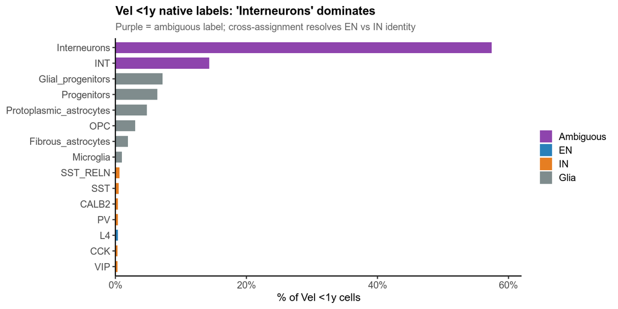

**Figure S7.** Velmeshev native (paper) cell type labels for the <1y age bin used in the cross-assignment experiments (n = 20,000 cells). ‘Interneurons’ is the single largest class (57.4%), followed by ‘INT’ (14.3%), both potentially inhibitory by name. Whether these cells are transcriptionally EN or IN is the subject of Experiments 1 and 2.

```r
vel_native <- tribble(
  ~label,                    ~pct,  ~broad_class,
  "Interneurons",            57.4,  "Ambiguous",
  "INT",                     14.3,  "Ambiguous",
  "Glial_progenitors",        7.2,  "Glia",
  "Progenitors",              6.4,  "Glia",
  "Protoplasmic_astrocytes",  4.8,  "Glia",
  "OPC",                      3.0,  "Glia",
  "Fibrous_astrocytes",       1.9,  "Glia",
  "Microglia",                1.0,  "Glia",
  "SST_RELN",                 0.6,  "IN",
  "SST",                      0.5,  "IN",
  "CALB2",                    0.4,  "IN",
  "PV",                       0.4,  "IN",
  "L4",                       0.4,  "EN",
  "CCK",                      0.3,  "IN",
  "VIP",                      0.3,  "IN"
) |>
  mutate(
    label = factor(label, levels = rev(label)),
    broad_class = factor(broad_class, levels = c("Ambiguous","EN","IN","Glia"))
  )

CLASS_COLS <- c("Ambiguous" = "#8E44AD", "EN" = "#2980B9", "IN" = "#E67E22", "Glia" = "#7F8C8D")

ggplot(vel_native, aes(x = label, y = pct, fill = broad_class)) +
  geom_col(width = 0.7) +
  coord_flip() +
  scale_fill_manual(values = CLASS_COLS) +
  scale_y_continuous(expand = expansion(mult = c(0, 0.08)),
                     labels = label_percent(scale = 1)) +
  labs(x = NULL, y = "% of Vel <1y cells",
       title = "Vel <1y native labels: 'Interneurons' dominates",
       subtitle = "Purple = ambiguous label; cross-assignment resolves EN vs IN identity",
       fill = "Broad class") +
  theme_pub()
```

### 7.2 Experiment 1: Vel Native Labels → Classify PsychAD Cells

**Design:** scANVI was trained using Vel native (paper) labels as supervision (`use_raw_labels: true`) and all PsychAD cells as Unknown. scANVI must therefore assign each PsychAD cell to the closest Vel native type — including “Interneurons”, “INT”, “L4”, “SST”, “PV”, “VIP”, etc.

**Key question:** Do PsychAD <1y cells cluster with Vel “Interneurons” (which would suggest they are EN-like), or with canonical IN types (SST/PV/VIP)?

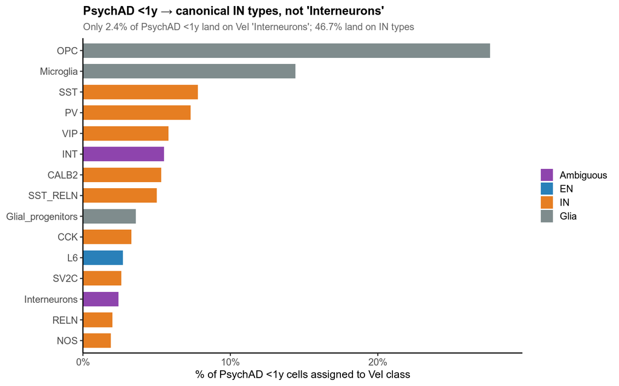

**Figure S8.** Classification of PsychAD <1y cells (n = 20,000) under Vel native label supervision (Experiment 1). Each PsychAD cell is assigned the nearest Vel native type by scANVI. Only 2.4% land on ‘Interneurons’; the majority land on OPC (27.6%), Microglia (14.4%), and canonical inhibitory types — SST (7.8%), PV (7.3%), VIP (5.8%), INT (5.5%), CALB2 (5.3%), SST_RELN (5.0%). This result demonstrates that PsychAD <1y cells are transcriptionally closer to cardinal interneurons than to Vel ‘Interneurons’.

```r
exp1_psych <- tribble(
  ~label,                    ~pct,  ~broad_class,
  "OPC",                     27.6,  "Glia",
  "Microglia",               14.4,  "Glia",
  "SST",                      7.8,  "IN",
  "PV",                       7.3,  "IN",
  "VIP",                      5.8,  "IN",
  "INT",                      5.5,  "Ambiguous",
  "CALB2",                    5.3,  "IN",
  "SST_RELN",                 5.0,  "IN",
  "Glial_progenitors",        3.6,  "Glia",
  "CCK",                      3.3,  "IN",
  "L6",                       2.7,  "EN",
  "SV2C",                     2.6,  "IN",
  "Interneurons",             2.4,  "Ambiguous",
  "RELN",                     2.0,  "IN",
  "NOS",                      1.9,  "IN"
) |>
  mutate(
    label = factor(label, levels = rev(label)),
    broad_class = factor(broad_class, levels = c("Ambiguous","EN","IN","Glia"))
  )

ggplot(exp1_psych, aes(x = label, y = pct, fill = broad_class)) +
  geom_col(width = 0.7) +
  coord_flip() +
  scale_fill_manual(values = CLASS_COLS) +
  scale_y_continuous(expand = expansion(mult = c(0, 0.08)),
                     labels = label_percent(scale = 1)) +
  labs(x = NULL, y = "% of PsychAD <1y cells assigned to Vel class",
       title = "PsychAD <1y → canonical IN types, not 'Interneurons'",
       subtitle = "Only 2.4% of PsychAD <1y land on Vel 'Interneurons'; 46.7% land on IN types",
       fill = "Broad class") +
  theme_pub()
```

**Interpretation:** PsychAD <1y cells are classified as genuine canonical inhibitory neurons (SST, PV, VIP) at high frequency. The 2.4% that land on “Interneurons” represents a small minority. This rules out the hypothesis that PsychAD “immature neurons” are simply the same cells as Vel “Interneurons” expressed in a different latent space due to batch effects. The PsychAD <1y IN-enrichment is real.

### 7.3 Experiment 2: PsychAD Native Labels → Classify Vel Cells

**Design:** scANVI was trained using PsychAD native HBCC subclass labels as supervision (`use_raw_labels: true`) and all Vel cells as Unknown. Each Vel cell is assigned the nearest PsychAD subclass (EN_L2_3_IT, IN_SST, IN_PVALB, OPC, etc.). The scVI model from Experiment 1 was reused (symlink); only the scANVI label assignment changes.

**Key question:** When placed in PsychAD label space, do Vel “Interneurons” land on EN or IN subtypes?

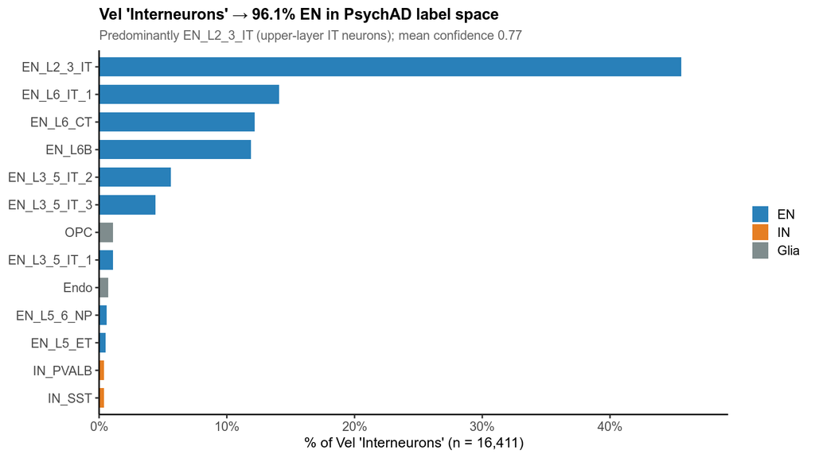

```r
vel_interneurons_exp2 <- tribble(
  ~label,          ~pct,   ~med_conf, ~broad_class,
  "EN_L2_3_IT",    45.6,   0.94,      "EN",
  "EN_L6_IT_1",    14.1,   0.87,      "EN",
  "EN_L6_CT",      12.2,   0.65,      "EN",
  "EN_L6B",        11.9,   0.84,      "EN",
  "EN_L3_5_IT_2",   5.6,   0.80,      "EN",
  "EN_L3_5_IT_3",   4.4,   0.99,      "EN",
  "OPC",            1.1,   0.54,      "Glia",
  "EN_L3_5_IT_1",   1.1,   0.79,      "EN",
  "Endo",           0.7,   0.33,      "Glia",
  "EN_L5_6_NP",     0.6,   0.90,      "EN",
  "EN_L5_ET",       0.5,   0.85,      "EN",
  "IN_PVALB",       0.4,   0.56,      "IN",
  "IN_SST",         0.4,   0.60,      "IN"
) |>
  mutate(
    label = factor(label, levels = rev(label)),
    broad_class = factor(broad_class, levels = c("EN","IN","Glia"))
  )

EN_IN_COLS <- c("EN" = "#2980B9", "IN" = "#E67E22", "Glia" = "#7F8C8D")

ggplot(vel_interneurons_exp2, aes(x = label, y = pct, fill = broad_class)) +
  geom_col(width = 0.7) +
  coord_flip() +
  scale_fill_manual(values = EN_IN_COLS) +
  scale_y_continuous(expand = expansion(mult = c(0, 0.08)),
                     labels = label_percent(scale = 1)) +
  labs(x = NULL, y = "% of Vel 'Interneurons' (n = 16,411)",
       title = "Vel 'Interneurons' → 96.1% EN in PsychAD label space",
       subtitle = "Predominantly EN_L2_3_IT (upper-layer IT neurons); mean confidence 0.77",
       fill = NULL) +
  theme_pub()
```

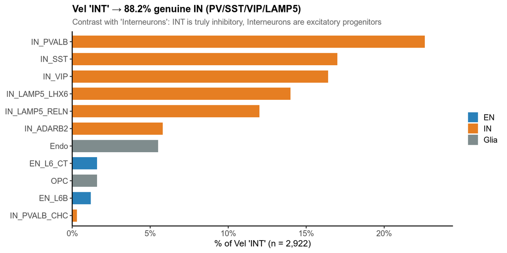

**Figure S10.** Top PsychAD subclass assignments for Vel ‘INT’ (n = 2,922 cells). 88.2% land on canonical inhibitory subtypes (PV, SST, VIP, LAMP5), confirming that Vel ‘INT’ represents genuine cortical interneurons. The sharp contrast with ‘Interneurons’ (96.1% EN) validates the EN/IN distinction within the Vel vocabulary.

```r
vel_int_exp2 <- tribble(
  ~label,             ~pct,  ~broad_class,
  "IN_PVALB",         22.6,  "IN",
  "IN_SST",           17.0,  "IN",
  "IN_VIP",           16.4,  "IN",
  "IN_LAMP5_LHX6",    14.0,  "IN",
  "IN_LAMP5_RELN",    12.0,  "IN",
  "IN_ADARB2",         5.8,  "IN",
  "Endo",              5.5,  "Glia",
  "EN_L6_CT",          1.6,  "EN",
  "OPC",               1.6,  "Glia",
  "EN_L6B",            1.2,  "EN",
  "IN_PVALB_CHC",      0.3,  "IN"
) |>
  mutate(
    label = factor(label, levels = rev(label)),
    broad_class = factor(broad_class, levels = c("EN","IN","Glia"))
  )

ggplot(vel_int_exp2, aes(x = label, y = pct, fill = broad_class)) +
  geom_col(width = 0.7) +
  coord_flip() +
  scale_fill_manual(values = EN_IN_COLS) +
  scale_y_continuous(expand = expansion(mult = c(0, 0.08)),
                     labels = label_percent(scale = 1)) +
  labs(x = NULL, y = "% of Vel 'INT' (n = 2,922)",
       title = "Vel 'INT' → 88.2% genuine IN (PV/SST/VIP/LAMP5)",
       subtitle = "Contrast with 'Interneurons': INT is truly inhibitory, Interneurons are excitatory progenitors",
       fill = NULL) +
  theme_pub()
```

### 7.4 Vel Native Label × PsychAD Subclass Cross-Tab

```r
crosstab_compact <- tribble(
  ~`Vel native label`,           ~N,      ~`EN%`,  ~`IN%`,  ~`Glia%`, ~Interpretation,
  "Interneurons",                16411,    96.1,     1.6,     2.3,     "Immature upper-layer EN progenitors",
  "Protoplasmic_astrocytes",      4610,     0.5,     0.0,    99.5,     "Astrocyte",
  "INT",                          2922,     3.6,    88.2,     8.1,     "Genuine cortical interneurons",
  "OPC",                          2585,     0.2,     0.0,    99.8,     "OPC",
  "Glial_progenitors",            1450,    29.7,     0.3,    70.0,     "Mixed EN/glia transitional",
  "L4",                           1275,    99.6,     0.1,     0.3,     "Layer IV EN",
  "Progenitors",                  1271,    43.3,    26.6,    30.1,     "Mixed transitional (+ Endo)",
  "L2-3",                         1239,   100.0,     0.0,     0.0,     "Upper-layer EN (L2–3)",
  "Microglia",                    1075,     1.5,    95.5,     3.0,     "Microglia (Vel label maps to Micro)",
  "Oligos",                       1069,     0.0,     0.0,   100.0,     "Oligodendrocyte",
  "CALB2",                        1015,     6.9,    89.3,     3.8,     "Genuine IN",
  "PV",                            916,     9.4,    86.6,     4.0,     "Genuine PV IN",
  "SST",                           830,     2.0,    97.7,     0.2,     "Genuine SST IN",
  "L6",                            503,    97.4,     0.0,     2.6,     "Layer VI EN",
  "SST_RELN",                      488,     0.2,    99.8,     0.0,     "Genuine SST/RELN IN",
  "Fibrous_astrocytes",            460,     0.2,     0.2,    99.6,     "Astrocyte",
  "VIP",                           451,     1.1,    98.9,     0.0,     "Genuine VIP IN",
  "CCK",                           341,     0.0,   100.0,     0.0,     "Genuine IN",
  "RELN",                          238,     0.0,   100.0,     0.0,     "Genuine IN",
  "SV2C",                          226,     0.0,   100.0,     0.0,     "Genuine IN",
  "L5",                            183,    93.4,     0.0,     6.6,     "Layer V EN",
  "NOS",                           170,     3.5,    95.9,     0.6,     "Genuine IN",
  "PV_MP",                         152,     2.6,    95.4,     2.0,     "Genuine IN",
  "L5-6-IT",                       106,   100.0,     0.0,     0.0,     "Deep-layer IT EN",
  "SP",                             14,   100.0,     0.0,     0.0,     "Subplate EN"
)

knitr::kable(
  crosstab_compact,
  caption = "**Table S4.** Vel native label × PsychAD subclass cross-assignment (Experiment 2). All 40,000 Vel cells; sorted by N descending. EN% = fraction assigned to EN_ subtypes; IN% = fraction assigned to IN_ subtypes; Glia% = remainder. Note: 'Microglia' in Vel maps 95.5% to Micro/Microglia in PsychAD, which the diagnostic script classifies as IN-like — this reflects the Micro/Microglia label convention, not genuine inhibitory identity.",
  align = c("l","r","r","r","r","l"),
  format.args = list(big.mark = ",")
)
```

**Table S4.** Vel native label × PsychAD subclass cross-assignment (Experiment 2). All 40,000 Vel cells; sorted by N descending. EN% = fraction assigned to EN_ subtypes; IN% = fraction assigned to IN_ subtypes; Glia% = remainder. Note: ‘Microglia’ in Vel maps 95.5% to Micro/Microglia in PsychAD, which the diagnostic script classifies as IN-like — this reflects the Micro/Microglia label convention, not genuine inhibitory identity.

| Vel native label | N | EN% | IN% | Glia% | Interpretation |
| --- | --- | --- | --- | --- | --- |
| Interneurons | 16,411 | 96.1 | 1.6 | 2.3 | Immature upper-layer EN progenitors |
| Protoplasmic_astrocytes | 4,610 | 0.5 | 0.0 | 99.5 | Astrocyte |
| INT | 2,922 | 3.6 | 88.2 | 8.1 | Genuine cortical interneurons |
| OPC | 2,585 | 0.2 | 0.0 | 99.8 | OPC |
| Glial_progenitors | 1,450 | 29.7 | 0.3 | 70.0 | Mixed EN/glia transitional |
| L4 | 1,275 | 99.6 | 0.1 | 0.3 | Layer IV EN |
| Progenitors | 1,271 | 43.3 | 26.6 | 30.1 | Mixed transitional (+ Endo) |
| L2-3 | 1,239 | 100.0 | 0.0 | 0.0 | Upper-layer EN (L2–3) |
| Microglia | 1,075 | 1.5 | 95.5 | 3.0 | Microglia (Vel label maps to Micro) |
| Oligos | 1,069 | 0.0 | 0.0 | 100.0 | Oligodendrocyte |
| CALB2 | 1,015 | 6.9 | 89.3 | 3.8 | Genuine IN |
| PV | 916 | 9.4 | 86.6 | 4.0 | Genuine PV IN |
| SST | 830 | 2.0 | 97.7 | 0.2 | Genuine SST IN |
| L6 | 503 | 97.4 | 0.0 | 2.6 | Layer VI EN |
| SST_RELN | 488 | 0.2 | 99.8 | 0.0 | Genuine SST/RELN IN |
| Fibrous_astrocytes | 460 | 0.2 | 0.2 | 99.6 | Astrocyte |
| VIP | 451 | 1.1 | 98.9 | 0.0 | Genuine VIP IN |
| CCK | 341 | 0.0 | 100.0 | 0.0 | Genuine IN |
| RELN | 238 | 0.0 | 100.0 | 0.0 | Genuine IN |
| SV2C | 226 | 0.0 | 100.0 | 0.0 | Genuine IN |
| L5 | 183 | 93.4 | 0.0 | 6.6 | Layer V EN |
| NOS | 170 | 3.5 | 95.9 | 0.6 | Genuine IN |
| PV_MP | 152 | 2.6 | 95.4 | 2.0 | Genuine IN |
| L5-6-IT | 106 | 100.0 | 0.0 | 0.0 | Deep-layer IT EN |
| SP | 14 | 100.0 | 0.0 | 0.0 | Subplate EN |

### 7.5 Cell Composition Comparison by Age Bin

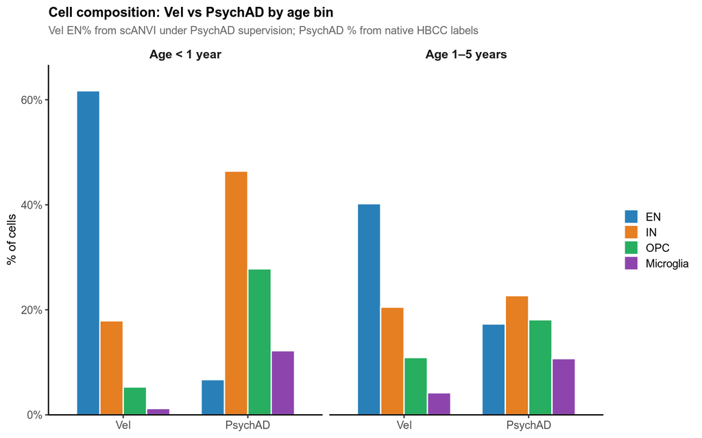

**Figure S11.** Cell type composition (EN%, IN%, OPC%, Micro%) for Velmeshev and PsychAD cells in the <1y and 1–5y age bins, using PsychAD native subclass labels throughout (Experiment 2: Vel cells classified by scANVI; PsychAD cells = native annotation). At <1y, the two datasets are dramatically divergent: Vel is EN-dominated (61.7%) with low IN (17.9%), while PsychAD is IN-dominated (46.4%) with very low EN (6.7%). By 1–5y, IN% converges (Vel 20.5% vs PsychAD 22.7%), though PsychAD remains lower in EN (17.3% vs Vel 40.2%). The convergence of IN% by 1–5y is consistent with both datasets capturing the same maturing interneuron population; the persistent EN% discrepancy suggests PsychAD continues to undersample upper-layer excitatory neurons relative to Vel.

```r
composition_data <- tribble(
  ~age_bin, ~source,    ~EN_pct, ~IN_pct, ~OPC_pct, ~Micro_pct, ~n,
  "<1y",    "Vel",       61.7,    17.9,    5.3,       1.2,       20000,
  "<1y",    "PsychAD",    6.7,    46.4,   27.8,      12.2,       20000,
  "1–5y",   "Vel",       40.2,    20.5,   10.9,       4.2,       20000,
  "1–5y",   "PsychAD",   17.3,    22.7,   18.1,      10.7,       20000
) |>
  pivot_longer(c(EN_pct, IN_pct, OPC_pct, Micro_pct),
               names_to = "cell_class", values_to = "pct") |>
  mutate(
    cell_class = recode(cell_class,
      "EN_pct" = "EN", "IN_pct" = "IN", "OPC_pct" = "OPC", "Micro_pct" = "Microglia"
    ),
    cell_class = factor(cell_class, levels = c("EN","IN","OPC","Microglia")),
    source = factor(source, levels = c("Vel","PsychAD")),
    age_bin = factor(age_bin, levels = c("<1y","1–5y"))
  )

CELL_COLS <- c("EN" = "#2980B9", "IN" = "#E67E22", "OPC" = "#27AE60", "Microglia" = "#8E44AD")

ggplot(composition_data, aes(x = source, y = pct, fill = cell_class)) +
  geom_col(position = "dodge", width = 0.75, colour = "white") +
  facet_wrap(~age_bin, labeller = labeller(age_bin = c("<1y" = "Age < 1 year", "1–5y" = "Age 1–5 years"))) +
  scale_fill_manual(values = CELL_COLS) +
  scale_y_continuous(labels = label_percent(scale = 1),
                     expand = expansion(mult = c(0, 0.08))) +
  labs(
    x = NULL, y = "% of cells", fill = "Cell class",
    title = "Cell composition: Vel vs PsychAD by age bin",
    subtitle = "Vel EN% from scANVI under PsychAD supervision; PsychAD % from native HBCC labels"
  ) +
  theme_pub() +
  theme(legend.position = "right")
```

```r
en_in_summary <- tribble(
  ~`Age bin`, ~Source,    ~N,      ~`EN%`, ~`IN%`, ~`EN/IN ratio`, ~`OPC%`, ~`Micro%`,
  "<1y",      "Vel",      20000,   61.7,   17.9,   3.45,            5.3,     1.2,
  "<1y",      "PsychAD",  20000,    6.7,   46.4,   0.14,           27.8,    12.2,
  "1–5y",     "Vel",      20000,   40.2,   20.5,   1.96,           10.9,     4.2,
  "1–5y",     "PsychAD",  20000,   17.3,   22.7,   0.76,           18.1,    10.7
)

knitr::kable(
  en_in_summary,
  caption = "**Table S5.** EN/IN/OPC/Microglia fractions for Vel and PsychAD cells by age bin. Vel fractions are from scANVI classification under PsychAD supervision (Experiment 2); PsychAD fractions are from native HBCC subclass labels. The EN/IN ratio inverts between datasets at <1y (Vel 3.45 vs PsychAD 0.14). By 1–5y, IN% converges to within 2 percentage points (Vel 20.5% vs PsychAD 22.7%), while EN% remains 2.3× higher in Vel (40.2% vs 17.3%).",
  align = c("l","l","r","r","r","r","r","r"),
  format.args = list(big.mark = ",")
)
```

**Table S5.** EN/IN/OPC/Microglia fractions for Vel and PsychAD cells by age bin. Vel fractions are from scANVI classification under PsychAD supervision (Experiment 2); PsychAD fractions are from native HBCC subclass labels. The EN/IN ratio inverts between datasets at <1y (Vel 3.45 vs PsychAD 0.14). By 1–5y, IN% converges to within 2 percentage points (Vel 20.5% vs PsychAD 22.7%), while EN% remains 2.3× higher in Vel (40.2% vs 17.3%).

| Age bin | Source | N | EN% | IN% | EN/IN ratio | OPC% | Micro% |
| --- | --- | --- | --- | --- | --- | --- | --- |
| <1y | Vel | 20,000 | 61.7 | 17.9 | 3.45 | 5.3 | 1.2 |
| <1y | PsychAD | 20,000 | 6.7 | 46.4 | 0.14 | 27.8 | 12.2 |
| 1–5y | Vel | 20,000 | 40.2 | 20.5 | 1.96 | 10.9 | 4.2 |
| 1–5y | PsychAD | 20,000 | 17.3 | 22.7 | 0.76 | 18.1 | 10.7 |